# Predicting NCAA Divison 1 Men’s Tennis Nationals Matches with the help of Machine Learning

```r
library(ggplot2)
library(grid)
library(gridExtra)
library(vtable)
library(rnaturalearth)
library(rnaturalearthdata)
library(sf)
library(stringi)
library(corrplot)
library(splitTools)
library(pROC)
library(glmnet)
library(kableExtra)
```

## Data

### Motivation

The motivation to collect the dataset was to use it to build a machine learning model to predict NCAA Division 1 men’s tennis nationals matches. The dataset is created by Kartikeya Sharma on behalf of the final project for the CIS 670 Data Science class at the University of Oregon. There have not been any funding provided to create this dataset, though I need to purchase a $10 subscription of Universal Tennis Ratings to get the precise UTR ratings of the colleges and the players.

### Composition

The data comprises of two different datasets, **combined_features_with_national_qualifiers.csv** and **college_results.csv**. The data is collected for the year 2021-2022 and contains all possible instances for that year.

| Variables | Description |
| --- | --- |
| name | Name of the college tennis program |
| ita_school_id | School Id used on the ITA tennis website |
| ita_team_id | Team Id used on the ITA tennis website |
| latlng | Latitude and Longitude of the location of the college tennis program |
| total_players | Number of Players in a team for the year 2021-2022 |
| total_dual_matches | Number of dual matches played by a team for the year 2021-2022 |
| total_points_won | Total points won by a team for the year 2021-2022 |
| total_points_lost | Total points lost by a team for the year 2021-2022 |
| power6_avg | UTR average for the best 6 players on the team for the year 2021-2022 |
| power6 | Sum of the UTR for the best 6 players on the team on the date when the data is collected which is 5/22/2022 |
| power6_high | Best UTR on the team of the top 6 players when the data is collected which is 5/22/2022 |
| power6_low | Worst UTR on the team of the top 6 players the data is collected which is 5/22/2022 |
| win_percentage | Win percentage for the year 2021-2022 |
| loss_percentage | Loss percentage for the year 2021-2022 |
| home_win_percentage | Home Win percentage for the year 2021-2022 |
| home_loss_percentage | Home Loss percentage for the year 2021-2022 |
| away_win_percentage | Away win percentage for the year 2021-2022 |
| away_loss_percentage | Away loss percentage for the year 2021-2022 |
| number_of_international_percentage | Percentage of international players on the team for the year 2021-2022 |
| number_of_americans_percentage | Percentage of american players on the team for the year 2021-2022 |
| countries | Different countries represented on the team for the year 2021-2022 |
| is_national_qualifier | If a team has qualified for nationals or not for the year 2021-2022 |

**college_results.csv** contains the information regarding all the D-1 matches played in 2021-2022. The total number of rows for this dataset is 2856. The columns/features for the above dataset are as follows:

| Variables | Description |
| --- | --- |
| team_0_id | Team Id from the ITA tennis website for the team 0 |
| team_1_id | Team Id from the ITA tennis website for the team 1 |
| won | 0 or 1. If 0 team_0 won the match or If 1 team_1 won the match. This column will be used as a target variable. |

There could be possibility of errors in the data collected. For example, the number of players are incorrect, players nationality is incorrect, the location of the college is incorrect, every match is not reported on the ITA website etc. The source of error would be the source of data but not the method of collection.

The sub population can be identified by columns such as *countries* or *is_national_qualifier*.

The data is not offensive, insulting or threatening. Also the data doesn’t include any private information as everything is available online for the public to view.

### Collection

The dataset is acquired/collected using the APIs of two websites which are *https://colleges.wearecollegetennis.com* and *https://app.universaltennis.com/*. You need to pay $10/month to acquire precise UTR rating’s data from the *https://app.universaltennis.com/*. The data is collected by writing python scripts and saving the collected data as csv files. The python scripts and csv files would be included in the final project submission.

The UTR data was collected on 5/22/2022. The College tennis results, demographics and win/loss data was collected over the span of a week between 5/16/2022 - 5/22/2022 as the API was timing out so I need to wait.

API documentation was not explicitly provided by either websites. I figured it out by inspecting the requests in the Google Chrome Devtools.

### Preprocessing/Cleaning/Labeling

At first the dataset is preprocessed while collecting with python scripts and saved in the csv format. The scripts will be provided as part of the project.

The dataset was further processed with R scripts as the processes such as merge, select, remove etc are applied so that we can come up with the above two datasets. The scripts will be provided as part of the project. There was also some manual processing needed as the name of the colleges in the data received from the ITA website and the name of the colleges in the data received from the UTR website are different. I needed to find which names are different and manually correct them. No labeling was required as the data collected was labeled. The label in the question is basically which of the team won or loss the match.

### Uses

There could be many different ways the data can be used:

1. To predict the winner of a dual men’s college tennis match.
2. To gain insights about the demographics in men’s college tennis.
3. To predict the number of points a team will win in a year based on the different features available in the dataset.

### Distributiion

There are currently no plans to make this data publicly available but if you want to use this data for your project, you can email me at ksharma@uoregon.edu. If in future, I make this data publicly available, it could be found on my [github](https://github.com/kartikeyas00).

### Maintenance

Currently there are no plans for maintaining this dataset but you can follow me on [github](https://github.com/kartikeyas00) for any updates.

```r
college.features = read.csv("data/processed/combined/combined_features_with_national_qualifiers.csv")
college.matches = read.csv('data/processed/ita/college_results.csv')
```

## Questions

1. How accurately a Machine Learning model predict the winner of a NCAA Division 1 National Dual Matches given the limited amount of data?
2. What features would be most important in the predictions?

## Visualization

### Exploratory Data Visualization

First we would like to explore different features present in **combined_features_with_national_qualifiers.csv** through visualization and summary statistics.

```r
## Matches and Points
st(college.features[,c("total_dual_matches", "total_points_won", "total_points_lost")],
   labels=c('Total Dual Matches', 'Total Points Won', 'Total Points Lost'),
   title='Summary Statistics (Matches and Points)',
   col.align = 'right',
   out="return"
   ) %>%
  kbl(caption = "Summary Statistics (Matches and Points)") %>%
  kable_styling()
```

Summary Statistics (Matches and Points)

| Variable | N | Mean | Std. Dev. | Min | Pctl. 25 | Pctl. 75 | Max |
| --- | --- | --- | --- | --- | --- | --- | --- |
| Total Dual Matches | 236 | 23.369 | 4.491 | 14 | 21 | 26 | 43 |
| Total Points Won | 236 | 75.763 | 29.871 | 1 | 54 | 92 | 206 |
| Total Points Lost | 236 | 70.504 | 19.556 | 28 | 58.75 | 80.25 | 177 |

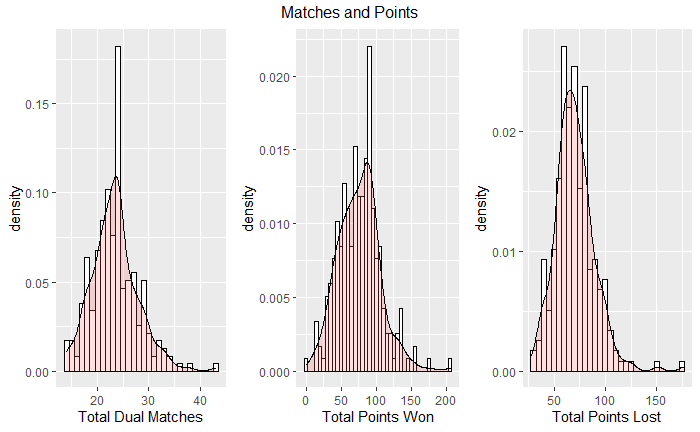

```r
#total_dual_matches
total_dual_matches = (ggplot(college.features, aes(x=total_dual_matches))
+ geom_histogram(aes(y=..density..),binwidth=1,color="black", fill="white")
+ geom_density(alpha=.2, fill="#FF6666")
+ labs(x='Total Dual Matches')
)
#total_points_won
total_points_won = (ggplot(college.features, aes(x=total_points_won))
  + geom_histogram(aes(y=..density..),binwidth=5,color="black", fill="white")
  + geom_density(alpha=.2, fill="#FF6666")
  + labs(x='Total Points Won')
)
#total_points_lost
total_points_lost = (ggplot(college.features, aes(x=total_points_lost))
  + geom_histogram(aes(y=..density..),binwidth=5,color="black", fill="white")
  + geom_density(alpha=.2, fill="#FF6666")
  + labs(x='Total Points Lost')
)
grid.arrange(total_dual_matches,
             total_points_won,
             total_points_lost,
             nrow = 1,
             top = "Matches and Points")
```

```r
##Universal Tennis Ratings
st(college.features[,c("power6_avg", "power6", "power6_high", "power6_low")],
   labels=c('Power6 (Average)', 'Power6', 'Power6(high)', 'Power6(low)'),
   title='Summary Statistics (Universal Tennis Ratings)',
   out="return")%>%
  kbl(caption = "Summary Statistics (Universal Tennis Ratings)") %>%
  kable_styling()
```

Summary Statistics (Universal Tennis Ratings)

| Variable | N | Mean | Std. Dev. | Min | Pctl. 25 | Pctl. 75 | Max |
| --- | --- | --- | --- | --- | --- | --- | --- |
| Power6 (Average) | 236 | 61.672 | 6.947 | 28.396 | 58.165 | 66.342 | 72.847 |
| Power6 | 236 | 70.535 | 7.396 | 19.09 | 67.317 | 75.007 | 82.24 |
| Power6(high) | 236 | 12.406 | 0.857 | 9.61 | 11.808 | 13.03 | 14.22 |
| Power6(low) | 236 | 11.301 | 1.134 | 7.26 | 10.598 | 12.097 | 13.39 |

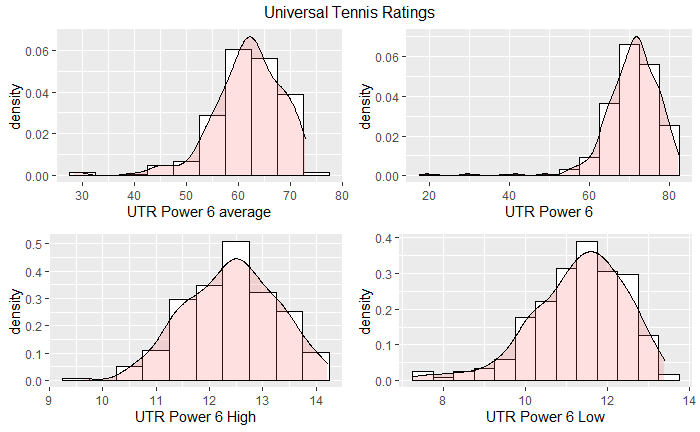

```r
#power6_avg
power6_avg = (ggplot(college.features, aes(x=power6_avg))
  + geom_histogram(aes(y=..density..),binwidth=5,color="black", fill="white")
  + geom_density(alpha=.2, fill="#FF6666")
  + labs(x='UTR Power 6 average')
)
#power6
power6 = (ggplot(college.features, aes(x=power6))
  + geom_histogram(aes(y=..density..),binwidth=5,color="black", fill="white")
  + geom_density(alpha=.2, fill="#FF6666")
  + labs(x='UTR Power 6')
)
#power6_high
power6_high = (ggplot(college.features, aes(x=power6_high))
  + geom_histogram(aes(y=..density..),binwidth=0.5,color="black", fill="white")
  + geom_density(alpha=.2, fill="#FF6666")
  + labs(x='UTR Power 6 High')
)
#power6_low
power6_low = (ggplot(college.features, aes(x=power6_low))
  + geom_histogram(aes(y=..density..),binwidth=0.5,color="black", fill="white")
  + geom_density(alpha=.2, fill="#FF6666")
  + labs(x='UTR Power 6 Low')
)
grid.arrange(power6_avg,
             power6,
             power6_high,
             power6_low,
             nrow = 2,
             top = "Universal Tennis Ratings")
```

```r
# Win/Loss Percentage
st(college.features[,c("win_percentage", "loss_percentage",
                       "home_win_percentage", "home_loss_percentage",
                       "away_win_percentage", "away_loss_percentage")],
   labels=c('Win(%)', 'Loss(%)', 'Home Win(%)',
            'Home Loss(%)', 'Away Win(%)','Away Loss(%)' ),
   title='Summary Statistics (Win/Loss Percentage)',
   out="return")%>%
  kbl(caption = "Summary Statistics (Win/Loss Percentage)") %>%
  kable_styling()
```

Summary Statistics (Win/Loss Percentage)

| Variable | N | Mean | Std. Dev. | Min | Pctl. 25 | Pctl. 75 | Max |
| --- | --- | --- | --- | --- | --- | --- | --- |
| Win(%) | 236 | 0.502 | 0.193 | 0 | 0.373 | 0.651 | 0.897 |
| Loss(%) | 236 | 0.498 | 0.193 | 0.103 | 0.349 | 0.627 | 1 |
| Home Win(%) | 236 | 0.68 | 0.238 | 0 | 0.5 | 0.857 | 1 |
| Home Loss(%) | 236 | 0.315 | 0.235 | 0 | 0.143 | 0.5 | 1 |
| Away Win(%) | 236 | 0.366 | 0.195 | 0 | 0.231 | 0.5 | 0.909 |
| Away Loss(%) | 236 | 0.634 | 0.195 | 0.091 | 0.5 | 0.769 | 1 |

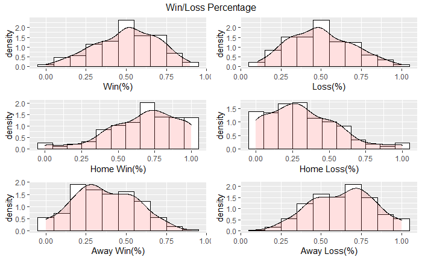

```r
#win_percentage
win_percentage=(ggplot(college.features, aes(x=win_percentage))
  + geom_histogram(aes(y=..density..),binwidth=0.1,color="black", fill="white")
  + geom_density(alpha=.2, fill="#FF6666")
  + labs(x='Win(%)')
)
#loss_percentage
loss_percentage=(ggplot(college.features, aes(x=loss_percentage))
  + geom_histogram(aes(y=..density..),binwidth=0.1,color="black", fill="white")
  + geom_density(alpha=.2, fill="#FF6666")
  + labs(x='Loss(%)')
)
#home_win_percentage
home_win_percentage=(ggplot(college.features, aes(x=home_win_percentage))
  + geom_histogram(aes(y=..density..),binwidth=0.1,color="black", fill="white")
  + geom_density(alpha=.2, fill="#FF6666")
  + labs(x='Home Win(%)')
)
#home_loss_percentage
home_loss_percentage=(ggplot(college.features, aes(x=home_loss_percentage))
  + geom_histogram(aes(y=..density..),binwidth=0.1,color="black", fill="white")
  + geom_density(alpha=.2, fill="#FF6666")
  + labs(x='Home Loss(%)')
)
#away_win_percentage
away_win_percentage=(ggplot(college.features, aes(x=away_win_percentage))
  + geom_histogram(aes(y=..density..),binwidth=0.1,color="black", fill="white")
  + geom_density(alpha=.2, fill="#FF6666")
  + labs(x='Away Win(%)')
)
#away_loss_percentage
away_loss_percentage=(ggplot(college.features, aes(x=away_loss_percentage))
  + geom_histogram(aes(y=..density..),binwidth=0.1,color="black", fill="white")
  + geom_density(alpha=.2, fill="#FF6666")
  + labs(x='Away Loss(%)')
)
grid.arrange(
            win_percentage,
            loss_percentage,
            home_win_percentage,
            home_loss_percentage,
            away_win_percentage,
            away_loss_percentage,
             nrow = 3,
             top = "Win/Loss Percentage")
```

```r
#Player Demographics
st(college.features[,c("total_players", "number_of_americans_percentage",
                       "number_of_international_percentage")],
   labels=c('Total Players', 'Number of American(%)', 'Number of International(%)'),
   title='Summary Statistics (Player Demographics)',
   out="return")%>%
  kbl(caption = "Summary Statistics (Player Demographics)") %>%
  kable_styling()
```

Summary Statistics (Player Demographics)

| Variable | N | Mean | Std. Dev. | Min | Pctl. 25 | Pctl. 75 | Max |
| --- | --- | --- | --- | --- | --- | --- | --- |
| Total Players | 236 | 10.068 | 2.149 | 5 | 9 | 11 | 18 |
| Number of American(%) | 236 | 0.399 | 0.28 | 0 | 0.167 | 0.587 | 1 |
| Number of International(%) | 236 | 0.601 | 0.28 | 0 | 0.413 | 0.833 | 1 |

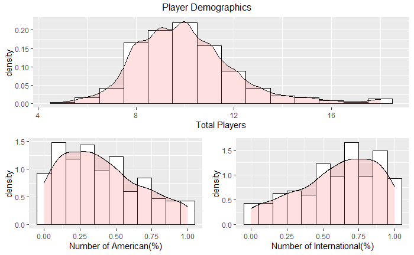

```r
#total_players
total_players = (ggplot(college.features, aes(x=total_players))
  + geom_histogram(aes(y=..density..),binwidth=1,color="black", fill="white")
  + geom_density(alpha=.2, fill="#FF6666")
  + labs(x='Total Players'))
#number_of_americans_percentage
number_of_americans_percentage = (ggplot(college.features, aes(x=number_of_americans_percentage))
  + geom_histogram(aes(y=..density..),binwidth=.1,color="black", fill="white")
  + geom_density(alpha=.2, fill="#FF6666")
  + labs(x='Number of American(%)'))
#number_of_international_percentage
number_of_international_percentage = (ggplot(college.features, aes(x=number_of_international_percentage))
  + geom_histogram(aes(y=..density..),binwidth=.1,color="black", fill="white")
  + geom_density(alpha=.2, fill="#FF6666")
  + labs(x='Number of International(%)'))
grid.arrange(total_players,
             number_of_americans_percentage,
             number_of_international_percentage,
             layout_matrix = rbind(c(1,1),c(2,3)),
             nrow = 2,
             top="Player Demographics")
```

### Findings

1. In the group **Matches and Points**, all the features looks normally distributed with slightly skewed on the right. This means some teams played a lot of matches during the year and it resulted into more points won as well as lost.
2. In the group **Universal Tennis Ratings** power6_avg and power6 are skewed to the left while power6_high and power6_low looks more normally distributed. It means that there are less schools whose combined UTRs are less than 60.
3. In the group **Win/Loss Percentage**, overall win and overall loss looks normally distributed. The Home Win (%) and Home (%) loss percent are skewed to the left and to the right respectively which means that it is less likely that team will loose at home or in other words it is more likely that the team will win at home. Away Win (%) and Away Loss (%) are skewed to the right and the left but not as much as compared to Home Win/Loss (%). This tells us that it is less likely to have more than 75% win on the road.
4. In the group **Player Demographics**, the number are slightly skewed to the right but mostly the distribution looks normal or Gaussian. It tells us that it is less likely that the teams would have more than 15 players on the roster. By looking at the number of international or american percentage we can see that there are more international on a college team compared to the Americans.

I am amazed by so many different countries represented in NCAA Tennis, hence less look at where the athletes coming from and how many different teams a country is representing.

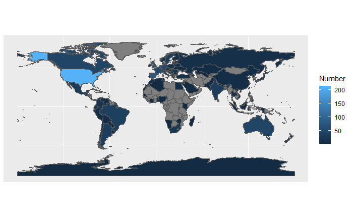

```r
world = ne_countries(scale = "medium", returnclass = "sf")
vectorize_stri_extract_all_words = Vectorize(stri_extract_all_words)
all_countries =table(unlist(vectorize_stri_extract_all_words(college.features$countries)))
df_all_countries = as.data.frame(all_countries)
colnames(df_all_countries) = c('CountryCode', 'Number')
df_all_countries = merge(df_all_countries, world, by.x="CountryCode", by.y="iso_a3", all.y=TRUE)[,c('CountryCode', 'Number', 'geometry')]
df_all_countries=st_sf(df_all_countries)
(ggplot(data = df_all_countries)
  + geom_sf(aes(fill = Number)))
```

From the above map one can see that a wide range of countries are represented at the college tennis which could be one of the reason for the success of the college team as if they can’t get a good player from USA then they give the scholarship to a really good international player.

Let’s look at the top 10 countries represented at NCAA D-1 Tennis.

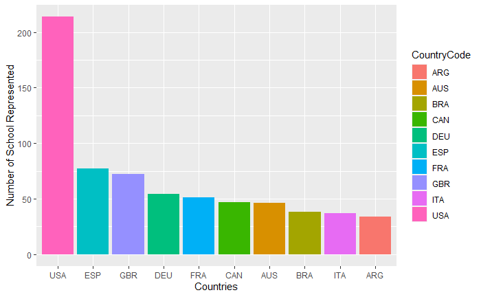

```r
df_all_countries_top_10 = head(df_all_countries[order(df_all_countries$Number, decreasing=TRUE), ], 10)
(ggplot(data=df_all_countries_top_10, aes(x=reorder(CountryCode, -Number), y=Number, fill = CountryCode)) +
  geom_bar(stat="identity")
  + labs(x='Countries', y="Number of School Represented"))
```

From the above bar chart we can see, USA is the most represented country while the second closest to USA is actually a lot below in terms of representation. The representation of countries from 5-10 are actually very close in terms of numbers.

### Incorporating features into college results data

In the previous section we explored the features of all the colleges in NCAA D-1 tennis. Now is the time to incorporate those features into **college_results.csv**. In this data, a row is a match where there are three columns *team_0_id*, *team_1_id* and *won*. Now we will be matching the data for each team and would be taking the difference of the features of two team i.e. feature(team_0) - feature(team_1).

```r
college.matches.features = merge(college.matches, college.features,
                                 by = intersect(names(college.matches),
                                                names(college.features)),
                                 by.x = 'team_0_id', by.y = 'ita_team_id')
colnames(college.matches.features) = c(head(colnames(college.matches.features),3),
                                       paste0("team_0_", tail(colnames(college.matches.features),-3)))
college.matches.features = merge(college.matches.features, college.features,
                                 by = intersect(names(college.matches), names(college.features)),
                                 by.x = 'team_1_id', by.y = 'ita_team_id')
colnames(college.matches.features) = c(head(colnames(college.matches.features),24),
                                       paste0("team_1_", tail(colnames(college.matches.features),-24)))
college.matches.features = college.matches.features[, !(names(college.matches.features) %in% c('team_0_name', 'team_0_ita_school_id','team_0_latlng','team_0_countries', 'team_0_is_national_qualifier', 'team_1_name','team_1_ita_school_id', 'team_1_latlng',
'team_1_countries', 'team_1_is_national_qualifier'))]
idx_vect=c(4:19)
colnames_vect = colnames(college.matches.features)
for(i in idx_vect){
  col_name_1 = colnames_vect[i]
  col_name_2 = colnames_vect[i+16]
  new_col_name = paste0(stri_replace(col_name_1, fixed='team_0_',''), '_difference')
  college.matches.features[,new_col_name] = college.matches.features[,col_name_1] - college.matches.features[, col_name_2]
  college.matches.features = college.matches.features[,!(names(college.matches.features) %in% c(col_name_1,col_name_2))]
}
```

Now let’s visualize the features

```r
## Matches and Points
st(college.matches.features[,c("total_dual_matches_difference", "total_points_won_difference", "total_points_lost_difference")],
   labels=c('Total Dual Matches (Diff)', 'Total Points Won (Diff)', 'Total Points Lost (Diff)'),
   title='Summary Statistics (Matches and Points)', out="return")%>%
  kbl(caption = "Summary Statistics (Matches and Points)") %>%
  kable_styling()
```

Summary Statistics (Matches and Points)

| Variable | N | Mean | Std. Dev. | Min | Pctl. 25 | Pctl. 75 | Max |
| --- | --- | --- | --- | --- | --- | --- | --- |
| Total Dual Matches (Diff) | 2530 | 1.22 | 5.487 | -21 | -2 | 4 | 29 |
| Total Points Won (Diff) | 2530 | 11.829 | 38.177 | -142 | -12 | 33.75 | 192 |
| Total Points Lost (Diff) | 2530 | -5.314 | 26.79 | -128 | -21 | 11 | 98 |

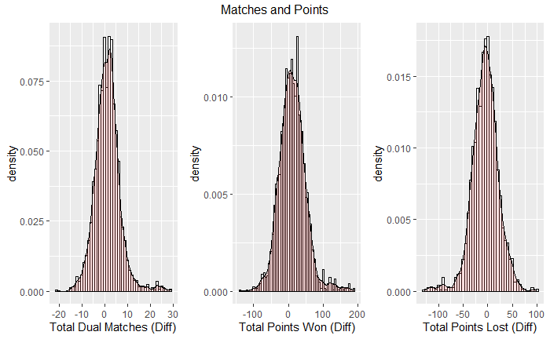

```r
#total_dual_matches
total_dual_matches = (ggplot(college.matches.features, aes(x=total_dual_matches_difference))
                      + geom_histogram(aes(y=..density..),binwidth=1,color="black", fill="white")
                      + geom_density(alpha=.2, fill="#FF6666")
                      + labs(x='Total Dual Matches (Diff)')
)
#total_points_won
total_points_won = (ggplot(college.matches.features, aes(x=total_points_won_difference))
                    + geom_histogram(aes(y=..density..),binwidth=5,color="black", fill="white")
                    + geom_density(alpha=.2, fill="#FF6666")
                    + labs(x='Total Points Won (Diff)')
)
#total_points_lost
total_points_lost = (ggplot(college.matches.features, aes(x=total_points_lost_difference))
                     + geom_histogram(aes(y=..density..),binwidth=5,color="black", fill="white")
                     + geom_density(alpha=.2, fill="#FF6666")
                     + labs(x='Total Points Lost (Diff)')
)
grid.arrange(total_dual_matches,
             total_points_won,
             total_points_lost,
             nrow = 1,
             top = "Matches and Points")
```

```r
##Universal Tennis Ratings
st(college.matches.features[,c("power6_avg_difference", "power6_difference",
                       "power6_high_difference", "power6_low_difference")],
   labels=c('Power6 (Average - Difference)', 'Power6 (Difference)', 'Power6(high-Difference)', 'Power6(low-Difference)'),
   title='Summary Statistics (Universal Tennis Ratings)',out="return")%>%
  kbl(caption = "Summary Statistics (Universal Tennis Ratings)") %>%
  kable_styling()
```

Summary Statistics (Universal Tennis Ratings)

| Variable | N | Mean | Std. Dev. | Min | Pctl. 25 | Pctl. 75 | Max |
| --- | --- | --- | --- | --- | --- | --- | --- |
| Power6 (Average - Difference) | 2530 | 1.691 | 6.552 | -34.57 | -1.691 | 4.495 | 35.189 |
| Power6 (Difference) | 2530 | 1.825 | 6.975 | -53.77 | -1.317 | 4.39 | 53.63 |
| Power6(high-Difference) | 2530 | 0.227 | 0.776 | -3.68 | -0.25 | 0.687 | 2.91 |
| Power6(low-Difference) | 2530 | 0.318 | 1.057 | -5.42 | -0.28 | 0.83 | 5.86 |

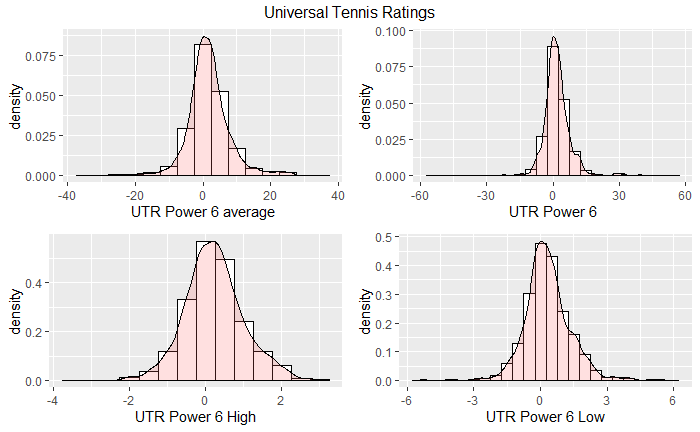

```r
#power6_avg
power6_avg = (ggplot(college.matches.features, aes(x=power6_avg_difference))
              + geom_histogram(aes(y=..density..),binwidth=5,color="black", fill="white")
              + geom_density(alpha=.2, fill="#FF6666")
              + labs(x='UTR Power 6 average')
)
#power6
power6 = (ggplot(college.matches.features, aes(x=power6_difference))
          + geom_histogram(aes(y=..density..),binwidth=5,color="black", fill="white")
          + geom_density(alpha=.2, fill="#FF6666")
          + labs(x='UTR Power 6')
)
#power6_high
power6_high = (ggplot(college.matches.features, aes(x=power6_high_difference))
               + geom_histogram(aes(y=..density..),binwidth=0.5,color="black", fill="white")
               + geom_density(alpha=.2, fill="#FF6666")
               + labs(x='UTR Power 6 High')
)
#power6_low
power6_low = (ggplot(college.matches.features, aes(x=power6_low_difference))
              + geom_histogram(aes(y=..density..),binwidth=0.5,color="black", fill="white")
              + geom_density(alpha=.2, fill="#FF6666")
              + labs(x='UTR Power 6 Low')
)
grid.arrange(power6_avg,
             power6,
             power6_high,
             power6_low,
             nrow = 2,
             top = "Universal Tennis Ratings")
```

```r
# Win/Loss Percentage
st(college.matches.features[,c("win_percentage_difference", "loss_percentage_difference",
                       "home_win_percentage_difference", "home_loss_percentage_difference",
                       "away_win_percentage_difference", "away_loss_percentage_difference")],
   labels=c('Win Diff(%)', 'Loss Diff(%)', 'Home Win Diff(%)',
            'Home Loss Diff(%)', 'Away Win Diff(%)','Away Loss Diff(%)' ),
   title='Summary Statistics (Win/Loss Percentage)',out="return")%>%
  kbl(caption = "Summary Statistics (Win/Loss Percentage)") %>%
  kable_styling()
```

Summary Statistics (Win/Loss Percentage)

| Variable | N | Mean | Std. Dev. | Min | Pctl. 25 | Pctl. 75 | Max |
| --- | --- | --- | --- | --- | --- | --- | --- |
| Win Diff(%) | 2530 | 0.068 | 0.246 | -0.706 | -0.098 | 0.238 | 0.7 |
| Loss Diff(%) | 2530 | -0.068 | 0.246 | -0.7 | -0.238 | 0.098 | 0.706 |
| Home Win Diff(%) | 2530 | 0.048 | 0.31 | -1 | -0.15 | 0.25 | 1 |
| Home Loss Diff(%) | 2530 | -0.041 | 0.305 | -1 | -0.249 | 0.16 | 1 |
| Away Win Diff(%) | 2530 | 0.057 | 0.261 | -0.714 | -0.118 | 0.243 | 0.786 |
| Away Loss Diff(%) | 2530 | -0.057 | 0.261 | -0.786 | -0.243 | 0.118 | 0.714 |

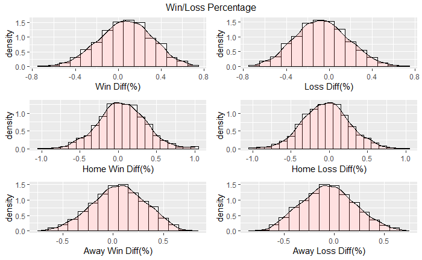

```r
#win_percentage
win_percentage=(ggplot(college.matches.features, aes(x=win_percentage_difference))
                + geom_histogram(aes(y=..density..),binwidth=0.1,color="black", fill="white")
                + geom_density(alpha=.2, fill="#FF6666")
                + labs(x='Win Diff(%)')
)
#loss_percentage
loss_percentage=(ggplot(college.matches.features, aes(x=loss_percentage_difference))
                 + geom_histogram(aes(y=..density..),binwidth=0.1,color="black", fill="white")
                 + geom_density(alpha=.2, fill="#FF6666")
                 + labs(x='Loss Diff(%)')
)
#home_win_percentage
home_win_percentage=(ggplot(college.matches.features, aes(x=home_win_percentage_difference))
                     + geom_histogram(aes(y=..density..),binwidth=0.1,color="black", fill="white")
                     + geom_density(alpha=.2, fill="#FF6666")
                     + labs(x='Home Win Diff(%)')
)
#home_loss_percentage
home_loss_percentage=(ggplot(college.matches.features, aes(x=home_loss_percentage_difference))
                      + geom_histogram(aes(y=..density..),binwidth=0.1,color="black", fill="white")
                      + geom_density(alpha=.2, fill="#FF6666")
                      + labs(x='Home Loss Diff(%)')
)
#away_win_percentage
away_win_percentage=(ggplot(college.matches.features, aes(x=away_win_percentage_difference))
                     + geom_histogram(aes(y=..density..),binwidth=0.1,color="black", fill="white")
                     + geom_density(alpha=.2, fill="#FF6666")
                     + labs(x='Away Win Diff(%)')
)
#away_loss_percentage
away_loss_percentage=(ggplot(college.matches.features, aes(x=away_loss_percentage_difference))
                      + geom_histogram(aes(y=..density..),binwidth=0.1,color="black", fill="white")
                      + geom_density(alpha=.2, fill="#FF6666")
                      + labs(x='Away Loss Diff(%)')
)
grid.arrange(
  win_percentage,
  loss_percentage,
  home_win_percentage,
  home_loss_percentage,
  away_win_percentage,
  away_loss_percentage,
  nrow = 3,
  top = "Win/Loss Percentage")
```

From all the above plots one can visually see the features are normally distributed. Now let’s check the correlation between different features.

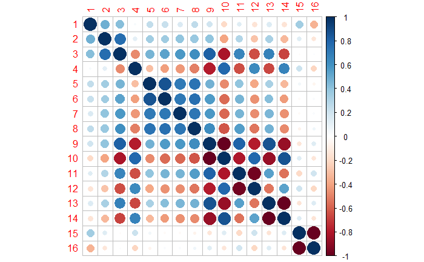

```r
res=cor(college.matches.features[,names(college.matches.features)[4:19]])
colnames(res) = c(1:16)
rownames(res) = c(1:16)
corrplot(res)
```

```r
legend = data.frame(Variable=c(names(college.matches.features)[4:19]), Label=c(1:16))
legend %>% kbl(caption = "Legend for the Correlation Plot") %>%
  kable_styling()
```

Legend for the Correlation Plot

| Variable | Label |
| --- | --- |
| total_players_difference | 1 |
| total_dual_matches_difference | 2 |
| total_points_won_difference | 3 |
| total_points_lost_difference | 4 |
| power6_avg_difference | 5 |
| power6_difference | 6 |
| power6_high_difference | 7 |
| power6_low_difference | 8 |
| win_percentage_difference | 9 |
| loss_percentage_difference | 10 |
| home_win_percentage_difference | 11 |
| home_loss_percentage_difference | 12 |
| away_win_percentage_difference | 13 |
| away_loss_percentage_difference | 14 |
| number_of_americans_percentage_difference | 15 |
| number_of_international_percentage_difference | 16 |

From the above correlation plot one can visually see that a lot features are highly correlated with each other. In this case we will set a correlation greater than 0.7 and smaller than -0.7 as a high correlation. According to that baseline the observations are following:

1. *total_dual_matches_difference* is highly correlated with *total_points_won_difference* .
2. *total_points_won_difference* is highly correlated with *win_percentage_difference* and *loss_percentage_difference*
3. *total_points_lost_difference* is highly correlated with *win_percentage_difference* and *loss_percentage_difference*
4. *power6_avg_difference* is highly correlated with *power6_difference*, *power6_high_difference* and *power6_low_difference*
5. *win_percentage_difference* is highly correlated with *loss_percentage_difference*, *home_win_percentage_difference*, *home_loss_percentage_difference*, *away_win_percentage_difference* and *away_loss_percentage_difference*.
6. *loss_percentage_difference* is highly correlated with *home_win_percentage_difference*, *home_loss_percentage_difference*, *away_win_percentage_difference* and *away_loss_percentage_difference*
7. *home_win_percentage_difference* is highly correlated to *home_loss_percentage_difference*

I would use the above information to fit the model and make it’s performance better.

## Models

```r
set.seed(3451)
inds = partition(college.matches.features$won, p = c(train = 0.7, test = 0.3))
train = college.matches.features[inds$train, ]
test = college.matches.features[inds$test, ]
```

### Logistic Regression

Let’s fit Logistic Regression model on the data and evaluate the results. But first define some functions which will help us to find various metrics such as Accuracy, F-1 Score, Precision and Recall.

```r
performance_metrics = function(confusion_metrics){
  TP = confusion_metrics[1]
  FP = confusion_metrics[3]
  FN = confusion_metrics[2]
  TN = confusion_metrics[4]
  accuracy = (TP+TN)/(TP+FP+FN+TN)
  precision = TP/(TP+FP)
  recall = TP/(TP+FN)
  f1 = 2 * ((precision*recall)/(precision+recall))
  all.metrics  = c('accuracy'=accuracy,
                   'precision'=precision,
                   'recall'=recall,
                   'f1'=f1)

  for (metric in names(all.metrics)){
    print(paste(metric, as.numeric(all.metrics[metric]), sep="---->")[1])
  }

  return(c(accuracy, precision, recall, f1))
}
```

#### Logistic Regression (All Variables)

First we will fit the Logistic Regression model on all variables and then will evaluate the results based on it.

```r
train.all.variable = train[,-c(1, 2)]
test.all.variable = test[,-c(1, 2)]
glm.fits.all.variable = glm(
  formula = won ~ ., data=train.all.variable, family=binomial
)
summary(glm.fits.all.variable)
```

```
Call:
glm(formula = won ~ ., family = binomial, data = train.all.variable)

Deviance Residuals:
    Min       1Q   Median       3Q      Max
-2.6044  -0.5363  -0.1575   0.4459   3.0705

Coefficients: (3 not defined because of singularities)
                                                Estimate Std. Error z value Pr(>|z|)
(Intercept)                                    -0.245965   0.073359  -3.353 0.000800 ***
total_players_difference                        0.053071   0.030839   1.721 0.085268 .
total_dual_matches_difference                  -0.176650   0.043923  -4.022 5.78e-05 ***
total_points_won_difference                     0.024597   0.007333   3.354 0.000796 ***
total_points_lost_difference                    0.009146   0.008516   1.074 0.282813
power6_avg_difference                          -0.029024   0.028036  -1.035 0.300551
power6_difference                              -0.023661   0.036981  -0.640 0.522295
power6_high_difference                         -0.958921   0.186875  -5.131 2.88e-07 ***
power6_low_difference                          -1.006552   0.170800  -5.893 3.79e-09 ***
win_percentage_difference                      -5.957267   1.452477  -4.101 4.11e-05 ***
loss_percentage_difference                            NA         NA      NA       NA
home_win_percentage_difference                -11.487536 387.147905  -0.030 0.976328
home_loss_percentage_difference               -11.550909 387.147702  -0.030 0.976198
away_win_percentage_difference                 -0.237390   0.668311  -0.355 0.722433
away_loss_percentage_difference                       NA         NA      NA       NA
number_of_americans_percentage_difference       0.391342   0.225859   1.733 0.083153 .
number_of_international_percentage_difference         NA         NA      NA       NA
---
Signif. codes:  0 ‘***’ 0.001 ‘**’ 0.01 ‘*’ 0.05 ‘.’ 0.1 ‘ ’ 1

(Dispersion parameter for binomial family taken to be 1)

    Null deviance: 2314.0  on 1769  degrees of freedom
Residual deviance: 1245.4  on 1756  degrees of freedom
AIC: 1273.4

Number of Fisher Scoring iterations: 14
```

```r
# evaluate on test data
glm.probs.all.variable.test=predict (glm.fits.all.variable , test.all.variable, type = "response")
glm.pred.all.variable.test = rep (0, dim(test.all.variable)[1])
glm.pred.all.variable.test[glm.probs.all.variable.test > .5] = 1
performance.metrics.all.variable.test =performance_metrics(table(glm.pred.all.variable.test, test.all.variable$won))
```

```
[1] "accuracy---->0.838157894736842"
[1] "precision---->0.860834990059642"
[1] "recall---->0.890946502057613"
[1] "f1---->0.875631951466127"
```

Now after looking at the summary of the above model it looks like there are multiple predictors who have p-value greater than 0.05 which means there is no clear evidence that the estimates between them and response variable *won* can be trusted. Also one important things to see in the summary above is that multiple variables have **N/A** values, after further investigation I found out that it is because of there is 100% correlation between these variables and some other variables in the data.

Let’s have a look at the ROC curve for the above model.

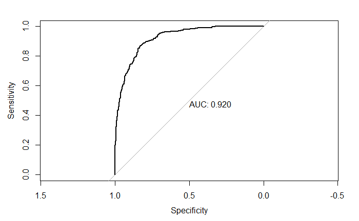

```r
test_prob = predict(glm.fits.all.variable, newdata = test.all.variable, type = "response")
test_roc = roc(test.all.variable$won ~ test_prob, plot = TRUE, print.auc = TRUE)
```

The Area Under the Curve or AUC is 0.92.

#### Logistic Regression (Removed Variables based on P-value)

Next thing I will like to do is to remove all the non significant variables and the variables which are 100% correlated.

```r
train.removed.variable = train[,c(3,4,5,6,10,11,12,18)]
test.removed.variable = test[,c(3,4,5,6,10,11,12,18)]
glm.fits.removed.variable = glm(
  formula = won ~ ., data=train.removed.variable, family=binomial
)
# evaluate on test data
glm.probs.removed.variable.test=predict (glm.fits.removed.variable , test.removed.variable, type = "response")
glm.pred.removed.variable.test = rep (0, dim(test.removed.variable)[1])
glm.pred.removed.variable.test[glm.probs.removed.variable.test > .5] = 1
performance.metrics.removed.variable.test =performance_metrics(table(glm.pred.removed.variable.test, test.removed.variable$won))
```

```
[1] "accuracy---->0.836842105263158"
[1] "precision---->0.859126984126984"
[1] "recall---->0.890946502057613"
[1] "f1---->0.874747474747475"
```

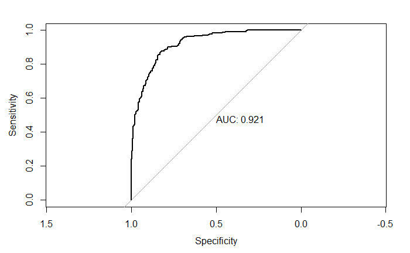

```r
test_prob = predict(glm.fits.removed.variable, newdata = test.removed.variable, type = "response")
test_roc = roc(test.removed.variable$won ~ test_prob, plot = TRUE, print.auc = TRUE)
```

The Area Under the Curve or AUC is 0.921. A very small improvement from the previous one.

#### Logistic Regression (Backward Selection AIC)

As the performance of our original model didn’t improve. Let’s use backward selection technique and evaluate the model performance.

```r
glm.fits.backward.selection <- step(glm.fits.all.variable, trace=0)
summary(glm.fits.backward.selection)
```

```
Call:
glm(formula = won ~ total_players_difference + total_dual_matches_difference +
    total_points_won_difference + power6_avg_difference + power6_high_difference +
    power6_low_difference + win_percentage_difference + number_of_americans_percentage_difference,
    family = binomial, data = train.all.variable)

Deviance Residuals:
    Min       1Q   Median       3Q      Max
-2.6376  -0.5384  -0.1640   0.4518   2.9278

Coefficients:
                                           Estimate Std. Error z value Pr(>|z|)
(Intercept)                               -0.251831   0.072202  -3.488 0.000487 ***
total_players_difference                   0.053200   0.030661   1.735 0.082725 .
total_dual_matches_difference             -0.145871   0.029987  -4.864 1.15e-06 ***
total_points_won_difference                0.022220   0.006733   3.300 0.000966 ***
power6_avg_difference                     -0.036473   0.022650  -1.610 0.107345
power6_high_difference                    -1.020988   0.172941  -5.904 3.55e-09 ***
power6_low_difference                     -1.069414   0.156602  -6.829 8.56e-12 ***
win_percentage_difference                 -6.840413   0.754579  -9.065  < 2e-16 ***
number_of_americans_percentage_difference  0.407752   0.221382   1.842 0.065497 .
---
Signif. codes:  0 ‘***’ 0.001 ‘**’ 0.01 ‘*’ 0.05 ‘.’ 0.1 ‘ ’ 1

(Dispersion parameter for binomial family taken to be 1)

    Null deviance: 2314.0  on 1769  degrees of freedom
Residual deviance: 1247.7  on 1761  degrees of freedom
AIC: 1265.7

Number of Fisher Scoring iterations: 6
```

```r
# accuracy on test data
glm.probs.backward.selection=predict (glm.fits.backward.selection , test.all.variable, type = "response")
glm.pred.backward.selection = rep (0, dim(test)[1])
glm.pred.backward.selection[glm.probs.backward.selection > .5] = 1
performance.metrics.backward.selection.test =performance_metrics(table(glm.pred.backward.selection, test.all.variable$won))
```

```
[1] "accuracy---->0.840789473684211"
[1] "precision---->0.862823061630219"
[1] "recall---->0.893004115226337"
[1] "f1---->0.877654196157735"
```

A slight performance increase can be seen from above. Now let’s check the ROC Curve

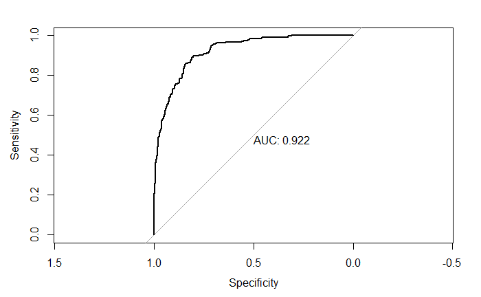

```r
test_prob = predict(glm.fits.backward.selection, newdata = test.all.variable, type = "response")
test_roc = roc(test.all.variable$won ~ test_prob, plot = TRUE, print.auc = TRUE)
```

This is again a small improvement from the previous model.

#### Logistic Regression (Backward Selection BIC)

Now Let’s try model selection with BIC criterion and evaluate the results.

```r
glm.fits.backward.selection.BIC <- step(glm.fits.all.variable, trace=0,k=log(nrow(train.all.variable)))
summary(glm.fits.backward.selection.BIC)
```

```
Call:
glm(formula = won ~ total_dual_matches_difference + total_points_won_difference +
    power6_high_difference + power6_low_difference + win_percentage_difference,
    family = binomial, data = train.all.variable)

Deviance Residuals:
    Min       1Q   Median       3Q      Max
-2.5910  -0.5365  -0.1746   0.4576   2.7879

Coefficients:
                               Estimate Std. Error z value Pr(>|z|)
(Intercept)                   -0.253148   0.070989  -3.566 0.000362 ***
total_dual_matches_difference -0.138951   0.029444  -4.719 2.37e-06 ***
total_points_won_difference    0.025603   0.006585   3.888 0.000101 ***
power6_high_difference        -1.149380   0.157966  -7.276 3.44e-13 ***
power6_low_difference         -1.119335   0.141633  -7.903 2.72e-15 ***
win_percentage_difference     -7.246091   0.744950  -9.727  < 2e-16 ***
---
Signif. codes:  0 ‘***’ 0.001 ‘**’ 0.01 ‘*’ 0.05 ‘.’ 0.1 ‘ ’ 1

(Dispersion parameter for binomial family taken to be 1)

    Null deviance: 2314  on 1769  degrees of freedom
Residual deviance: 1259  on 1764  degrees of freedom
AIC: 1271

Number of Fisher Scoring iterations: 6
```

```r
# accuracy on test data
glm.probs.backward.selection.BIC=predict (glm.fits.backward.selection.BIC , test.all.variable, type = "response")
glm.pred.backward.selection.BIC = rep (0, dim(test.all.variable)[1])
glm.pred.backward.selection.BIC[glm.probs.backward.selection.BIC > .5] = 1
performance.metrics.backward.selection.BIC.test =performance_metrics(table(glm.pred.backward.selection.BIC, test.all.variable$won))
```

```
[1] "accuracy---->0.838157894736842"
[1] "precision---->0.86372745490982"
[1] "recall---->0.886831275720165"
[1] "f1---->0.875126903553299"
```

The results did not improve but actually are a little worse than the previous model. Let’s plot the ROC curve.

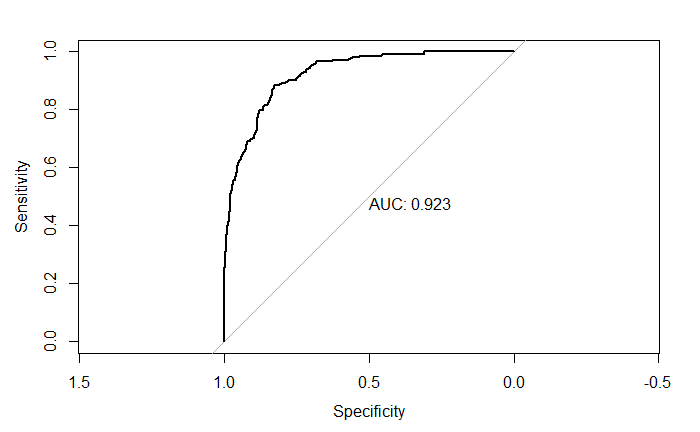

```r
test_prob = predict(glm.fits.backward.selection.BIC, newdata = test.all.variable, type = "response")
test_roc = roc(test.all.variable$won ~ test_prob, plot = TRUE, print.auc = TRUE)
```

But the AUC curve is actually a very small improvement than the last one.

#### Logistic Regression (Lasso)

Finally let’s try to build a better model with Lasso.

```r
train.lasso.X = as.matrix(train[,c(4:19)])
train.lasso.Y = train[,c(3)]
test.lasso.X = as.matrix(test[,c(4:19)])
test.lasso.Y = test[,c(3)]
glm.fits.lasso = glmnet(x=train.lasso.X, y=train.lasso.Y, family = "binomial")
glm.fits.lasso.cv = cv.glmnet(x=train.lasso.X, y=train.lasso.Y, family = "binomial", type.measure = "class")
glm.probs.lasso = predict(glm.fits.lasso, newx=test.lasso.X, s=glm.fits.lasso.cv$lambda.1se, type = "response")
glm.pred.lasso= rep (0, dim(test.lasso.X)[1])
glm.pred.lasso[glm.probs.lasso > .5] = 1
performance.lasso.test =performance_metrics(table(glm.pred.lasso, test.lasso.Y))
```

```
[1] "accuracy---->0.835526315789474"
[1] "precision---->0.846449136276392"
[1] "recall---->0.907407407407407"
[1] "f1---->0.875868917576961"
```

We can see there is not an improvement in the metrics besides recall which is compensated by low precision. Let’s plot the ROC curve and see if there is any improvement.

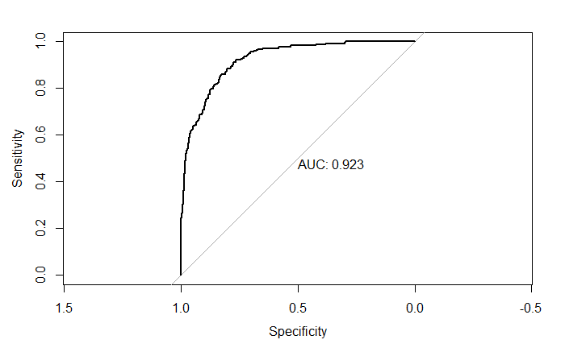

```r
test_prob = predict(glm.fits.lasso, newx=test.lasso.X, s=glm.fits.lasso.cv$lambda.1se, type = "response")
test_roc = roc(test.lasso.Y ~ test_prob, plot = TRUE, print.auc = TRUE)
```

The AUC doesn’t show any improvement when compares to the previous models.

#### Apply the above Models to to the NCAA D-1 Nationals tennis matches

Now let’s apply each model above to the NCAA D-1 Nationals matches. But first we need to do some feature incorporation as we did last time.

```r
college.matches.nationals = read.csv('data/processed/ita/college_results_nationals.csv')
college.matches.nationals.features = merge(college.matches.nationals, college.features,
                                 by = intersect(names(college.matches.nationals),
                                                names(college.features)),
                                 by.x = 'team_0_id', by.y = 'ita_team_id')
colnames(college.matches.nationals.features) = c(head(colnames(college.matches.nationals.features),3),
                                       paste0("team_0_", tail(colnames(college.matches.nationals.features),-3)))
college.matches.nationals.features = merge(college.matches.nationals.features, college.features,
                                 by = intersect(names(college.matches.nationals), names(college.features)),
                                 by.x = 'team_1_id', by.y = 'ita_team_id')
colnames(college.matches.nationals.features) = c(head(colnames(college.matches.nationals.features),24),
                                       paste0("team_1_", tail(colnames(college.matches.nationals.features),-24)))
college.matches.nationals.features = college.matches.nationals.features[, !(names(college.matches.nationals.features) %in% c('team_0_name', 'team_0_ita_school_id','team_0_latlng','team_0_countries', 'team_0_is_national_qualifier', 'team_1_name','team_1_ita_school_id', 'team_1_latlng',
'team_1_countries', 'team_1_is_national_qualifier'))]
idx_vect=c(4:19)
colnames_vect = colnames(college.matches.nationals.features)
for(i in idx_vect){
  col_name_1 = colnames_vect[i]
  col_name_2 = colnames_vect[i+16]
  new_col_name = paste0(stri_replace(col_name_1, fixed='team_0_',''), '_difference')
  college.matches.nationals.features[,new_col_name] = college.matches.nationals.features[,col_name_1] - college.matches.nationals.features[, col_name_2]
  college.matches.nationals.features = college.matches.nationals.features[,!(names(college.matches.nationals.features) %in% c(col_name_1,col_name_2))]
}
```

Now it’s time for predictions:

#### Logistic Regression (All Variables)

```r
glm.probs.all.variable.test=predict (glm.fits.all.variable , college.matches.nationals.features, type = "response")
glm.pred.all.variable.test = rep (0, dim(college.matches.nationals.features)[1])
glm.pred.all.variable.test[glm.probs.all.variable.test > .5] = 1
performance.metrics.all.variable.test =performance_metrics(table(glm.pred.all.variable.test, college.matches.nationals.features$won))
```

```
[1] "accuracy---->0.825396825396825"
[1] "precision---->0.905660377358491"
[1] "recall---->0.888888888888889"
[1] "f1---->0.897196261682243"
```

```r
test_prob = predict(glm.fits.all.variable, newdata = college.matches.nationals.features, type = "response")
test_roc = roc(college.matches.nationals.features$won ~ test_prob, plot = FALSE, print.auc = TRUE)
print(test_roc$auc)
```

```
Area under the curve: 0.8992
```

#### Logistic Regression (Removed Variables based on P-value)

```r
glm.probs.removed.variable.test =predict (glm.fits.removed.variable  , college.matches.nationals.features, type = "response")
glm.pred.removed.variable.test = rep (0, dim(college.matches.nationals.features)[1])
glm.pred.removed.variable.test[glm.probs.removed.variable.test > .5] = 1
performance.metrics.removed.variable.test =performance_metrics(table(glm.pred.removed.variable.test, college.matches.nationals.features$won))
```

```
[1] "accuracy---->0.841269841269841"
[1] "precision---->0.923076923076923"
[1] "recall---->0.888888888888889"
[1] "f1---->0.905660377358491"
```

```r
test_prob = predict(glm.fits.removed.variable, newdata = college.matches.nationals.features, type = "response")
test_roc = roc(college.matches.nationals.features$won ~ test_prob, plot = FALSE, print.auc = TRUE)
print(test_roc$auc)
```

```
Area under the curve: 0.8724
```

#### Logistic Regression (Backward Selection AIC)

```r
glm.probs.backward.selection.test =predict (glm.fits.backward.selection  , college.matches.nationals.features, type = "response")
glm.pred.backward.selection.test= rep (0, dim(college.matches.nationals.features)[1])
glm.pred.backward.selection.test[glm.probs.backward.selection.test > .5] = 1
performance.metrics.backward.selection.test =performance_metrics(table(glm.pred.backward.selection.test, college.matches.nationals.features$won))
```

```
[1] "accuracy---->0.841269841269841"
[1] "precision---->0.923076923076923"
[1] "recall---->0.888888888888889"
[1] "f1---->0.905660377358491"
```

```r
test_prob = predict(glm.fits.backward.selection, newdata = college.matches.nationals.features, type = "response")
test_roc = roc(college.matches.nationals.features$won ~ test_prob, plot = FALSE, print.auc = TRUE)
print(test_roc$auc)
```

```
Area under the curve: 0.8909
```

#### Logistic Regression (Backward Selection BIC)

```r
glm.probs.backward.selection.BIC =predict (glm.fits.backward.selection.BIC  , college.matches.nationals.features, type = "response")
glm.pred.backward.selection.BIC= rep (0, dim(college.matches.nationals.features)[1])
glm.pred.backward.selection.BIC[glm.probs.backward.selection.BIC > .5] = 1
performance.metrics.backward.selection.BIC.test =performance_metrics(table(glm.pred.backward.selection.BIC, college.matches.nationals.features$won))
```

```
[1] "accuracy---->0.825396825396825"
[1] "precision---->0.905660377358491"
[1] "recall---->0.888888888888889"
[1] "f1---->0.897196261682243"
```

```r
test_prob = predict(glm.fits.backward.selection.BIC, newdata = college.matches.nationals.features, type = "response")
test_roc = roc(college.matches.nationals.features$won ~ test_prob, plot = FALSE, print.auc = TRUE)
print(test_roc$auc)
```

```
Area under the curve: 0.8807
```

#### Logistic Regression (Lasso)

```r
college.matches.nationals.features.X = as.matrix(college.matches.nationals.features[,c(4:19)])
college.matches.nationals.features.Y = as.matrix(college.matches.nationals.features[,c(3)])
glm.probs.lasso = predict(glm.fits.lasso, newx=college.matches.nationals.features.X, s=glm.fits.lasso.cv$lambda.1se, type = "response")
glm.pred.lasso= rep (0, dim(college.matches.nationals.features.X)[1])
glm.pred.lasso[glm.probs.lasso > .5] = 1
performance.lasso.test =performance_metrics(table(glm.pred.lasso, college.matches.nationals.features.Y))
```

```
[1] "accuracy---->0.825396825396825"
[1] "precision---->0.905660377358491"
[1] "recall---->0.888888888888889"
[1] "f1---->0.897196261682243"
```

```r
test_prob = predict(glm.fits.lasso, newx=college.matches.nationals.features.X, s=glm.fits.lasso.cv$lambda.1se, type = "response")
test_roc = roc(college.matches.nationals.features.Y ~ test_prob, plot = FALSE, print.auc = TRUE)
print(test_roc$auc)
```

```
Area under the curve: 0.8621
```

## Results, Analysis, and Discussion

#### Comparison of all the models from the previous section on the Test Dataset

[output not shown]

#### Comparison of all the models from the previous section on NCAA D-1 Nationals Matches

| Model | Accuracy | Recall | Precision | F-1 | AUC |
| --- | --- | --- | --- | --- | --- |
| Logistic Regression (All Variables) | 82.53 | 88.88 | 90.56 | 89.71 | 0.899 |
| Logistic Regression (Removed Variables based on P-value) | 84.12 | 88.88 | 92.30 | 90.56 | 0.872 |
| Logistic Regression (Backward Selection AIC) | 84.12 | 88.88 | 92.30 | 90.56 | 0.890 |
| Logistic Regression (Backward Selection BIC) | 82.53 | 88.88 | 90.56 | 89.71 | 0.880 |
| Logistic Regression (Lasso) | 82.53 | 88.88 | 90.56 | 89.71 | 0.862 |

The results of all the different Logistic Regression models trained on training data are given in the above tables.

Our first question was about the accuracy and we can see there are multiple models which have same accuracies. Hence to break the tie we can look at the alternative metric which is AUC. The highest AUC is associated with Logistic Regression (All Variables) but it’s accuracy is not amongst the highest one so we can disregard it. Second highest AUC is associated with Logistic Regression (Backward Selection AIC). **Hence we can conclude that Logistic Regression (Backward Selection AIC) is the best model here.**

To answer our second question we need to look at the features selected by Logistic Regression (Backward Selection AIC) and they are:

- **total_players_difference**
- **total_dual_matches_difference**
- **total_points_won_difference**
- **power6_avg_difference**
- **power6_high_difference**
- **power6_low_difference**
- **win_percentage_difference**
- **number_of_americans_percentage_difference**

Now after looking at the above conclusions there are several questions which comes to the mind, they are:

**1) Why the feature selection doesn’t significantly improved the model?**

**2) Why the model was not able to predict the upsets correctly?**

To answer the first question, we need to go back to our visualizations where we saw that there are some variables which have very strong correlation with each other. When you think of that then one might want to choose only those features which are not very strongly correlated with each other but when we try to do that in this situation there is no significant increase in the accuracy. Similarly Backward Selection did select the features which gave a little better performance than the model with all the features but again the performance was not substantial. And finally Lasso method did not give substantial improvements but did improve the recall substantially. The F-1 score remained similar as other models so I would not consider it substantial improvement.

What I think is happening here is that most of the original features in the datasets are actually not introducing noise to the dataset thus removing them is not increasing the performance substantially. Though the logistic regression with all variables is removing the variables which are 100% correlated to other variables in the dataset automatically.

While feature selection is computationally expensive it does give a more interpretable model as well a slightly better performance (at least in my case). To further improve the model one can try methods like Principal Component Analysis, Data Standardization etc.

To answer the second question we would first see what matches have been predicted wrong by our model and investigate if they are the upsets or not.

```r
index = which(! (glm.pred.backward.selection.test == college.matches.nationals.features$won))
college.matches.wrong.predictions= college.matches.nationals.features[index,c(1,2,3)]
college.matches.wrong.predictions = merge(college.matches.wrong.predictions, college.features,
      by = intersect(names(college.matches.wrong.predictions),
                     names(college.features)),
      by.x = 'team_0_id', by.y = 'ita_team_id')[,c(2,3,4)]
colnames(college.matches.wrong.predictions)[3] = 'name_0'
college.matches.wrong.predictions = merge(college.matches.wrong.predictions, college.features,
                                           by = intersect(names(college.matches.wrong.predictions),
                                                          names(college.features)),
                                           by.x = 'team_1_id', by.y = 'ita_team_id')[,c(2,3,4)]
colnames(college.matches.wrong.predictions)[3] = 'name_1'
college.matches.wrong.predictions %>%
  kbl(caption="Wrong Predictions") %>%
  kable_styling()%>%
  row_spec(c(1,2,3,5, 7,8,10), bold = T, color = "white", background = "#D7261E")
```

Wrong Predictions

| won | name_0 | name_1 |
| --- | --- | --- |
| 0 | University of Kentucky | Ohio State University |
| 0 | Louisiana State University | Southern Methodist University |
| 1 | Texas Christian University | University of Kentucky |
| 1 | University of California, Irvine | University of California, San Diego |
| 1 | University of Georgia | Florida State University |
| 0 | University of North Carolina | University of Arizona |
| 0 | North Carolina State University | Middle Tennessee State University |
| 0 | University of Tennessee | Baylor University |
| 0 | University of Oklahoma | University of Louisville |
| 1 | University of Florida | University of Virginia |

The highlighted rows are the upsets which the model did not predict correctly and you can see the upsets makes most of the data above. Now there are several reasons I can think of which makes the model not able to predict upsets in an accurate manner:

1. Data doesn’t include features about the teams performance in the previous NCAA championships. It has been evident that some team perform better than others in the championship for various reasons such as the experience of the coaches, experience of the players playing at high level tennis tournaments before coming to college, weather conditions etc.
2. Data doesn’t include the features about the difficulty of the schedule for a certain team. Some teams play very difficult schedule such as playing Top-20 teams in the country and then coming into the tournament with lower ranking but great match practice.
3. Data is not realtime. The data we used in our prediction was static which means it was collected after the NCAA tournament. It could be possible that a day prior of the match, data could be different and the predictions can change.

To sum up, our model predicted the NCAA D-1 2022 Nationals Matches with 84.12% accuracy when Backward Selection (AIC) is applied to the original Logistic regression. To improve the model we should try other methods such as PCA, standardization etc and also should collect more features and realtime data.

## Impact

There could be two major impacts of this work:

1. Coaches using the model to recruit players and schedule matches.

College coaches can use this model and the features in the data to recruit the players which can closely resembles the features of a winning team. For example coaches can recruit players which can lead to a certain total UTR for a team or can recruit a certain percent of international players if they see team with high or low international players are having success. They can also use the model to determine the amount of matches and the difficulty of matches they should be playing so that they can come close to the features of a successful team. **Also please note, the measure of success should be defined by the coaches themselves.**

2. Sports Bettors can use this model to improve their bets.

Sports better can use this model or build a new model based on this to improve their bets on the college tennis matches. A realtime model can be built based on realtime data with similar features I used to give a realtime prediction for a certain match as the features change after every match. **Also please note I am not sure if it is ethical to use a Machine Learning model for betting or not.**